# Lead Testing Results for the City of St. Louis

Christopher Prener, Ph.D.

December 22, 2016

## Introduction

This tutorial introduces a number of skills related to mapping data in `R`: data cleaning, table joins, and map production. `R` is not a replacement for a GIS like ArcGIS or QGIS. However, its mapping tools are useful for previewing data and creating quick maps, particularly of quantitative data. `R` is also particularly useful for its spatial statistics tools.

## Packages

The following tutorial requires a number of packages from the `tidyverse` as well as other packages that facilitate mapping. If you need any of these packages, use the `install.packages("packageName")` function.

Note that you also need to have the package `rgeos` installed. It does not have to be loaded for this tutorial to work, but it must be present. Re-start RStudio after installing this package to ensure that you do not get any errors.

```r
# load required packages
library(dplyr) # data cleaning
library(rgdal) # read shapefiles
library(ggplot2) # create plots
library(maptools) # tools for mapping
# library(ggmap) # tools for mapping
library(RColorBrewer) # pre-defined color ramps
library(Cairo) # high quality output
```

## Data

The `csv` file included with this tutorial was created by exporting an attribute table from a U.S. Census TIGER/Line shapefile containing all current Census Tracts in the City of St. Louis.

The data (`countTested` and `pctElevated`) were obtained from the Reuters [report on lead poisoning](http://www.reuters.com/investigates/special-report/usa-lead-testing/) that was published on 19 Dec 2016. Each tract’s data was copied from [Reuters’ map](http://www.reuters.com/investigates/special-report/usa-lead-testing/#interactive-lead) to a `csv` file manually.

`countTested` refers to the number of children screened for blood lead levels in the tract between 2010 and 2015. `pctElevated` is the percentage of children tested who had blood lead levels greater than or equal to 5 micrograms per deciliter. These were the original two values obtained from Reuters’ reporting.

```r
lead <- read.csv("STLLead.csv", stringsAsFactors = FALSE)
head(lead)
```

|  | STATEFP | COUNTYFP | TRACTCE | GEOID | NAME | NAMELSAD | countTested | pctElevated |
| --- | --- | --- | --- | --- | --- | --- | --- | --- |
| 1 | 29 | 510 | 118100 | 29510118100 | 1181.00 | Census Tract 1181 | 345 | 9.57 |
| 2 | 29 | 510 | 117400 | 29510117400 | 1174.00 | Census Tract 1174 | 871 | 12.06 |
| 3 | 29 | 510 | 126700 | 29510126700 | 1267.00 | Census Tract 1267 | 458 | 18.12 |
| 4 | 29 | 510 | 119102 | 29510119102 | 1191.02 | Census Tract 1191.02 | 182 | 2.20 |
| 5 | 29 | 510 | 126800 | 29510126800 | 1268.00 | Census Tract 1268 | 486 | 4.73 |
| 6 | 29 | 510 | 126900 | 29510126900 | 1269.00 | Census Tract 1269 | 1296 | 15.66 |

## Data Cleaning

There are a number of geography variables that we do not need. We’ll start by creating a variable named `id` that contains the `GEOID` data stored as character values. This will be important for mapping our lead level data. We’ll then retain that new variable plus the `NAMELSAD` variable (useful for double-checking data) and our two data variables `countTested` and `pctElevated`.

```r
lead$id <- as.character(lead$GEOID) # reformat and rename GEOID
lead$name <- lead$NAMELSAD # rename NAMELSAD
# drop all variables except those listed
lead <- select(lead, id, name, countTested, pctElevated)
head(lead)
```

|  | id | name | countTested | pctElevated |
| --- | --- | --- | --- | --- |
| 1 | 29510118100 | Census Tract 1181 | 345 | 9.57 |
| 2 | 29510117400 | Census Tract 1174 | 871 | 12.06 |
| 3 | 29510126700 | Census Tract 1267 | 458 | 18.12 |
| 4 | 29510119102 | Census Tract 1191.02 | 182 | 2.20 |
| 5 | 29510126800 | Census Tract 1268 | 486 | 4.73 |
| 6 | 29510126900 | Census Tract 1269 | 1296 | 15.66 |

Next, we want to get the count of children with elevated blood lead levels rather than just the percentage:

```r
# create estimate of number of children with elevated blood lead levels
lead$estElevated <- round((lead$pctElevated*.01)*lead$countTested, digits = 0)
head(lead)
```

|  | id | name | countTested | pctElevated | estElevated |
| --- | --- | --- | --- | --- | --- |
| 1 | 29510118100 | Census Tract 1181 | 345 | 9.57 | 33 |
| 2 | 29510117400 | Census Tract 1174 | 871 | 12.06 | 105 |
| 3 | 29510126700 | Census Tract 1267 | 458 | 18.12 | 83 |
| 4 | 29510119102 | Census Tract 1191.02 | 182 | 2.20 | 4 |
| 5 | 29510126800 | Census Tract 1268 | 486 | 4.73 | 23 |
| 6 | 29510126900 | Census Tract 1269 | 1296 | 15.66 | 203 |

## Basic Mapping in `R`

The first step for mapping lead levels is to import a shapefile that contains Census Tract boundaries for the City of St. Louis. This is done using the `rgdal` package. If you want to reference a shapefile located in another directory, you can specificy the file path using `dsn = "filePath"`. Otherwise, include the period as below to reference a shapefile stored in your working directory.

In the layer option, include the name of the shapefile *without the extension*.

After loading the shapefile, use the `ggplot2` function `fortify()` to convert the data from a shapefile to a dataframe that we can plot using `ggplot2`. This will dramatically increase the number of observations, and will create a variable named `id` that includes the `GEOID` data specified under the `region` option below. This variable will be important for mapping our lead level data.

```r
# import shapefile
tract <- readOGR(dsn = ".", layer = "STLTracts")
# convert shapefile to dataframe
tract <- fortify(tract, region="GEOID")
```

You can get a preview of the tract boundaries by using `ggplot2` to map them quickly. The following example also provides a basic example for how to generate maps. A major difference between the following code and a typical ggplot is that the initial `ggplot()` function does not have a data source or asthetic specified. Instead, those details are supplied within `geom_polygon()`. This geom is ideal for mapping polygon spatial data. As shown below, at a minimum you need to specify a data source, the x and y variables (typically `x = long, y = lat`), and a group variable that uniquely identifies individual polygons.

The `coord_map()` function is a tool included with `ggplot2` that gives you access to projected coordinate systems included in the package `mapproj`. If nothing is included in the function, it will use the Mercator projection by default.

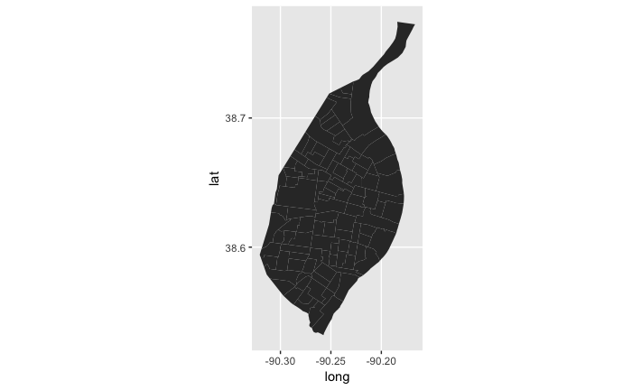

```r
ggplot() +
  geom_polygon(data = tract, aes(x = long, y = lat, group = id)) +
  coord_map()
```

## Mapping the Joined the Lead and Tract Data

To map the blood lead level data, we must first join it to the dataframe containing the tract polygons. We can do this using tools from `dplyr`, including the `left_join(dataSource, by "joinVar")` function. The `joinVar` should be identically named and stored in both dataframes. The pipe operator (`%>%`) allows us to join the data and immediately apply the combined dataset to a new dataframe.

```r
# join tables into new dataframe
leadTracts <- tract %>%
  left_join(lead, by = "id")
```

With the data joined, we can now map the perctage of children in each Census Tract that have elevated blood lead levels. We add the `fill = variable` option to map the quanities stored in a specific variable:

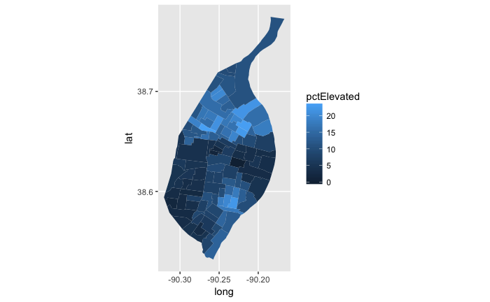

```r
ggplot() +
    geom_polygon(data = leadTracts, aes(x = long, y = lat, group = id, fill = pctElevated)) +
    coord_map()
```

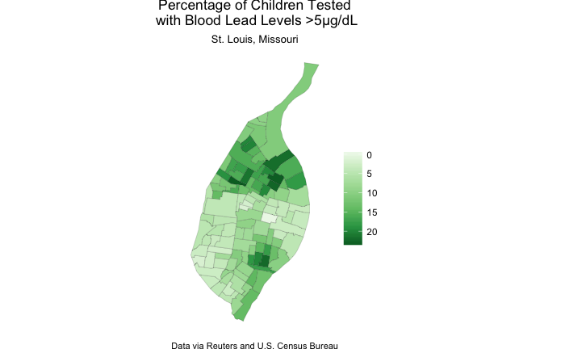

```r
# save final plot to object leadPlot
leadPlot <- ggplot() +
  geom_polygon(
    data = leadTracts,
    aes(x = long, y = lat, group = id, fill = pctElevated),
    color = "black", size = 0.05) +
  scale_fill_distiller(palette = "Greens", trans = "reverse") +
  coord_map() +
  theme_void() +
  labs(
    title = "Percentage of Children Tested\n with Blood Lead Levels >5µg/dL",
    subtitle = "St. Louis, Missouri",
    fill = "",
    caption = "Data via Reuters and U.S. Census Bureau") +
    theme(
      plot.title = element_text(hjust = 0.5),
      plot.subtitle = element_text(hjust = 0.5),
      plot.caption=element_text(size = rel(.75), hjust=0.5))
leadPlot
```

**Updated on September 26, 2017 to remove dependency on `ggmap`, which is currently broken. The `theme_void()` function is used instead of `ggmap`’s `theme_nothing(legend = TRUE)` function.**

## Saving Map Output

You can use the `ggsave()` function to save an already created plot:

```r
ggsave(leadPlot, file = "STLLead.png", width = 5, height = 5, type = "cairo-png")
```